# hw1_producing_features

# 1

### Task 1.1

Import the tweet data from this link.

```r
df <- read.csv("https://raw.githubusercontent.com/uo-datasci-specialization/c4-ml-fall-2021/main/data/tweet_sub.csv")

library(tidyverse)
library(lubridate)
library(recipes)
```

### Task 1.2

The time variable in this dataset is a character string such as Thu Jun 18 07:35:01 PDT 2009. Create four new columns in the dataset using this time variable to show the day, date, month, and hour of a tweet. The table below provides some examples of how these four new columns would look like given time as a character string. Make sure that day column is a numeric variable from 1 to 7 (Monday = 1, Sunday =7), date column is a numeric variable from 1 to 31, and hour column is a numeric variable from 0 to 23, and month column is a factor variable. Calculate and print the frequencies for each new column (day, month, date, and hour).

```r
df = df %>% mutate(
  date_format = parse_date_time(time, orders = '%a %b %d %T %Y'),
  day = wday(date_format, week_start = 1),
  month = factor(month(date_format)),
  date = day(date_format),
  hour = hour(date_format)
  )

head(df)
```

```
##   sentiment                         time
## 1  Negative Thu Jun 18 07:35:01 PDT 2009
## 2  Positive Sun May 10 00:31:52 PDT 2009
## 3  Positive Sun May 31 09:15:19 PDT 2009
## 4  Positive Fri May 22 07:25:52 PDT 2009
## 5  Positive Sun May 31 02:09:52 PDT 2009
## 6  Positive Sun Jun 07 09:13:08 PDT 2009
##                                                                                                                      tweet
## 1                                                                         I think my twitter is attackd by a kind of worm
## 2 @ddlovato demi if you can i think itd be amazing if you covered thats what you get by paramore haha im sure you know it
## 3                                       had so much fun yesterday hopes they play at the md agian  hhmmm what to do today?
## 4                                                                            @MlleNoir Si gentile. You are a big sweetie.
## 5         A Peek at the Logo for The Smurfs Movie http://tinyurl.com/kksrz3 (via @CSSHH) let's hope it's with real actors
## 6                                                                   Joined the Astrology Twibe  . Visit  http://is.gd/RJpB
##           date_format day month date hour
## 1 2009-06-18 07:35:01   4     6   18    7
## 2 2009-05-10 00:31:52   7     5   10    0
## 3 2009-05-31 09:15:19   7     5   31    9
## 4 2009-05-22 07:25:52   5     5   22    7
## 5 2009-05-31 02:09:52   7     5   31    2
## 6 2009-06-07 09:13:08   7     6    7    9
```

```r
str(df)
```

```
## 'data.frame':    1500 obs. of  8 variables:
##  $ sentiment  : chr  "Negative" "Positive" "Positive" "Positive" ...
##  $ time       : chr  "Thu Jun 18 07:35:01 PDT 2009" "Sun May 10 00:31:52 PDT 2009" "Sun May 31 09:15:19 PDT 2009" "Fri May 22 07:25:52 PDT 2009" ...
##  $ tweet      : chr  "I think my twitter is attackd by a kind of worm " "@ddlovato demi if you can i think itd be amazing if you covered thats what you get by paramore haha im sure you know it " "had so much fun yesterday hopes they play at the md agian  hhmmm what to do today?" "@MlleNoir Si gen…
##  $ date_format: POSIXct, format: "2009-06-18 07:35:01" "2009-05-10 00:31:52" ...
##  $ day        : num  4 7 7 5 7 7 3 1 2 6 ...
##  $ month      : Factor w/ 3 levels "4","5","6": 3 2 2 2 2 3 3 3 2 2 ...
##  $ date       : int  18 10 31 22 31 7 17 1 26 30 ...
##  $ hour       : int  7 0 9 7 2 9 16 6 22 0 ...
```

```r
df %>% count(day)
```

```
##   day   n
## 1   1 297
## 2   2 156
## 3   3  92
## 4   4 115
## 5   5 223
## 6   6 300
## 7   7 317
```

```r
df %>% count(month)
```

```
##   month   n
## 1     4  87
## 2     5 536
## 3     6 877
```

```r
df %>% count(date)
```

```
##    date   n
## 1     1 115
## 2     2  86
## 3     3  63
## 4     4  24
## 5     5  60
## 6     6  98
## 7     7  98
## 8     9  10
## 9    10  22
## 10   11   4
## 11   13   2
## 12   14  20
## 13   15  99
## 14   16  66
## 15   17  87
## 16   18  95
## 17   19  67
## 18   20  75
## 19   21  27
## 20   22  57
## 21   23  14
## 22   24   6
## 23   25  26
## 24   26  10
## 25   27   1
## 26   28  18
## 27   29  65
## 28   30  86
## 29   31  99
```

```r
df %>% count(hour)
```

```
##    hour  n
## 1     0 67
## 2     1 74
## 3     2 62
## 4     3 70
## 5     4 65
## 6     5 73
## 7     6 90
## 8     7 85
## 9     8 75
## 10    9 65
## 11   10 47
## 12   11 64
## 13   12 53
## 14   13 44
## 15   14 34
## 16   15 46
## 17   16 64
## 18   17 42
## 19   18 51
## 20   19 62
## 21   20 51
## 22   21 71
## 23   22 67
## 24   23 78
```

### Task 1.3

```r
df = df %>% mutate(
  sentiment = ifelse(sentiment == 'Positive', 1, 0))
```

### Task 1.4

Load the reticulate package and Python libraries (torch, numpy, transformers, nltk, and tokenizers). Then, load the text package. Using these packages, generate tweet embeddings for each tweet in this dataset using the roberta-base model, a pre-trained NLP model. Tweet embeddings for each tweet should be a vector of numbers with length 768. Append these embeddings to the original data.

*I ran this once and saved the variables in the environment. To increase speed, I am skipping the actual evaluation of this section of code and loaded the environment instead.*

```r
library(reticulate)
path_to_env <- "/usr/local/anaconda3/envs/r.python/"
use_condaenv(path_to_env)
py_discover_config()

import('numpy')
import('transformers')
import('nltk')
import('tokenizers')
import('torch')

t = map(df$tweet, textEmbed,
                  model = 'roberta-base',
                  layers = 12,
                  context_aggregation_layers = 'concatenate')

save.image(file='data/roberta-base_output.rdata')
```

```r
load("data/roberta-base_output.rdata")

sentence_num = t(sapply(t, `[[`, 1)) %>%
  data.frame() %>%
  map_dfr(as.numeric) %>%
  mutate(match_id = rownames(df))

df = df %>% mutate(match_id = rownames(df)) %>%
  inner_join(sentence_num, by = 'match_id')

head(df)
```

```
##   sentiment                         time
## 1         0 Thu Jun 18 07:35:01 PDT 2009
## 2         1 Sun May 10 00:31:52 PDT 2009
## 3         1 Sun May 31 09:15:19 PDT 2009
## 4         1 Fri May 22 07:25:52 PDT 2009
## 5         1 Sun May 31 02:09:52 PDT 2009
## 6         1 Sun Jun 07 09:13:08 PDT 2009
##                                                                                                                      tweet
## 1                                                                         I think my twitter is attackd by a kind of worm
## 2 @ddlovato demi if you can i think itd be amazing if you covered thats what you get by paramore haha im sure you know it
## 3                                       had so much fun yesterday hopes they play at the md agian  hhmmm what to do today?
## 4                                                                            @MlleNoir Si gentile. You are a big sweetie.
## 5         A Peek at the Logo for The Smurfs Movie http://tinyurl.com/kksrz3 (via @CSSHH) let's hope it's with real actors
## 6                                                                   Joined the Astrology Twibe  . Visit  http://is.gd/RJpB
##           date_format day month date hour match_id          Dim1        Dim2
```

[output cut: 902 more lines]

### Task 1.5

Remove the two columns time and tweet from the dataset as you do not need them anymore.

```r
df = df %>% select(-c(tweet, time, date_format, match_id))
```

### Task 1.6

Prepare a recipe using the recipe() and prep() functions from the recipes package for final transformation of the variables in this dataset.

```r
outcome = c('sentiment')

cylic <- c('day','date', 'hour')

categorical <- c('month')

numeric <- paste0('Dim',c(1:768))


blueprint <- recipe(x  = df,
                    vars  = c(numeric,cylic,categorical,outcome),
                    roles = c(rep('predictor',ncol(df)-1),'outcome')) %>%
  # each cyclic variable (day, date, and hour) is recoded into two new variables of sin and cos terms.
  step_harmonic(day, frequency = 1, cycle_size = 7) %>%
  step_harmonic(date, frequency = 1, cycle_size = 31) %>%
  step_harmonic(hour, frequency = 1, cycle_size = 12) %>%
  # all numerical embeddings (Dim1 - Dim768) are standardized (?step_normalize)
  step_normalize(all_of(numeric)) %>%
  # month variable is recoded into dummy variables using one-hot encoding (?step_dummy)
  step_dummy(month,one_hot=TRUE)

blueprint
```

```
## Recipe
##
## Inputs:
##
##       role #variables
##    outcome          1
##  predictor        772
##
## Operations:
##
## Harmonic numeric variables for day
## Harmonic numeric variables for date
## Harmonic numeric variables for hour
## Centering and scaling for all_of(numeric)
## Dummy variables from month
```

```r
prepare <- prep(blueprint,
                training = df)
```

### Task 1.7

Finally, apply this recipe to the whole dataset and obtain the final version of the dataset with transformed variables. The final dataset should have 1500 rows and 781 columns as the following:

```r
baked_df <- bake(prepare, new_data = df)

dim(baked_df)
```

```
## [1] 1500  781
```

```r
head(baked_df)
```

```
## # A tibble: 6 × 781
##      Dim1   Dim2   Dim3    Dim4   Dim5   Dim6    Dim7    Dim8   Dim9  Dim10
##     <dbl>  <dbl>  <dbl>   <dbl>  <dbl>  <dbl>   <dbl>   <dbl>  <dbl>  <dbl>
## 1 -0.205   0.285  1.16   0.911   0.256  0.456 -1.61    0.175   0.555  0.290
## 2  0.0302 -1.13  -0.179  0.874  -1.92  -0.293  1.19   -0.0667  1.53   1.43
## 3 -0.101  -1.23  -0.157  0.342  -0.572  0.364 -0.435  -0.763   1.70  -0.186
## 4 -1.12    1.51   0.619  0.0538  0.655  0.748 -0.0171  0.408  -1.17   0.485
## 5 -0.250  -0.570  0.165 -1.43   -0.159  0.865 -0.320   0.404   0.483 -0.719
## 6 -0.961  -1.25  -1.03   1.03    0.549 -0.839 -1.88    1.58   -0.825 -1.02
## # … with 771 more variables: Dim11 <dbl>, Dim12 <dbl>, Dim13 <dbl>,
## #   Dim14 <dbl>, Dim15 <dbl>, Dim16 <dbl>, Dim17 <dbl>, Dim18 <dbl>,
## #   Dim19 <dbl>, Dim20 <dbl>, Dim21 <dbl>, Dim22 <dbl>, Dim23 <dbl>,
## #   Dim24 <dbl>, Dim25 <dbl>, Dim26 <dbl>, Dim27 <dbl>, Dim28 <dbl>,
## #   Dim29 <dbl>, Dim30 <dbl>, Dim31 <dbl>, Dim32 <dbl>, Dim33 <dbl>,
## #   Dim34 <dbl>, Dim35 <dbl>, Dim36 <dbl>, Dim37 <dbl>, Dim38 <dbl>,
## #   Dim39 <dbl>, Dim40 <dbl>, Dim41 <dbl>, Dim42 <dbl>, Dim43 <dbl>, …
```

### Task 1.8

Remove the original day,date, and hour variables from the dataset as we do not need them anymore because we already created sin and cos terms for each one of them.

```r
baked_df = baked_df %>% select(-c(day, date, hour))
```

### Task 1.9

Export the final dataset (1500 x 778) as a .csv file and upload it to Canvas along your submission.

```r
write.csv(x=baked_df, file="data/hw1_data1_output.csv")
```

# 2

### Task 2.1

Import the Oregon testing data

```r
df2 <- read.csv("https://raw.githubusercontent.com/uo-datasci-specialization/c4-ml-fall-2021/main/data/oregon.csv")
```

### Task 2.2

The tst_dt variable is a character string such as 5/14/2018 0:00. Create two new columns in the dataset using this variable to show the date and month the test was taken. The table below provides some examples of how these two new columns would look like given tsd_dt as a character string. Make sure that both date and month columns are a numeric variables. Once you create these two new columns, remove the colun tst_dt from the dataset as you do not it anymore. Calculate and print the frequencies for the new columns (date and month)

```r
df2 = df2 %>% mutate(
  date_format = mdy_hm(tst_dt),
  month = month(date_format),
  date = day(date_format)
  ) %>%
  select(-c(tst_dt, date_format))
```

```r
df2 %>% count(date)
```

```
##    date     n
## 1     1  7490
## 2     2  3149
## 3     3  3225
## 4     4  5876
## 5     5  2957
## 6     6  1638
## 7     7  4569
## 8     8  5567
## 9     9  6787
## 10   10  7930
## 11   11  6015
## 12   12   618
## 13   13   158
## 14   14  5284
```

[output cut: 17 more lines]

```r
df2 %>% count(month)
```

```
##   month      n
## 1     2     33
## 2     3    421
## 3     4  13037
## 4     5 161473
## 5     6  14462
```

### Task 2.3

Using the ff_glimpse() function from the finalfit package, provide a snapshot of missingness in this dataset. This function also returns the number of levels for categorical variables. If there is any variable with large amount of missingness (e.g. more than 75%), remove this variable from the dataset.

```r
missing_info = finalfit::ff_glimpse(df2)

missing_info$Categorical[,c('n','missing_percent')]
```

```
##                          n missing_percent
## sex                 189426             0.0
## ethnic_cd           189426             0.0
## tst_bnch            189426             0.0
## migrant_ed_fg       189426             0.0
## ind_ed_fg           189365             0.0
## sp_ed_fg            189365             0.0
## tag_ed_fg           188963             0.2
## econ_dsvntg         188895             0.3
## ayp_lep              38087            79.9
## stay_in_dist        188963             0.2
## stay_in_schl        188963             0.2
## dist_sped           188963             0.2
## trgt_assist_fg      188956             0.2
## ayp_dist_partic     189426             0.0
## ayp_schl_partic     189426             0.0
## ayp_dist_prfrm      189426             0.0
## ayp_schl_prfrm      189426             0.0
## rc_dist_partic      189426             0.0
## rc_schl_partic      189426             0.0
## rc_dist_prfrm       189426             0.0
## rc_schl_prfrm       189426             0.0
## grp_rpt_dist_partic 189426             0.0
## grp_rpt_schl_partic 189426             0.0
## grp_rpt_dist_prfrm  189426             0.0
## grp_rpt_schl_prfrm  189426             0.0
```

```r
missing_info$Categorical[,c('n','missing_percent')] %>% filter(missing_percent >= 0.75)
```

```
##             n missing_percent
## ayp_lep 38087            79.9
```

```r
missing_info$Continuous[,c('n','missing_percent')]
```

```
##               n missing_percent
## id       189426             0.0
## enrl_grd 189426             0.0
## score    189426             0.0
## month    189426             0.0
## date     189426             0.0
```

```r
df2 = df2 %>% select(-ayp_lep)
```

### Task 2.4

Most of the variables in this dataset are categorical, and particularly a binary variable with a Yes and No response. Check the frequency of unique values for all categorical variables. If there is any inconsistency (e.g., Yes is coded as both ‘y’ and ‘Y’) for any of these variables in terms of how values are coded, fix them. Also, check the distribution of numeric variables and make sure there is no anomaly.

```r
df2[sapply(df2, is.character)] <- lapply(df2[sapply(df2, is.character)], as.factor)

str(df2)
```

```
## 'data.frame':    189426 obs. of  29 variables:
##  $ id                 : int  1 2 3 5 7 10 12 13 14 16 ...
##  $ sex                : Factor w/ 2 levels "F","M": 1 2 2 1 1 2 1 2 1 2 ...
##  $ ethnic_cd          : Factor w/ 7 levels "A","B","H","I",..: 3 7 5 3 3 3 7 7 7 5 ...
##  $ enrl_grd           : int  6 5 8 8 8 8 8 8 8 8 ...
##  $ tst_bnch           : Factor w/ 6 levels "1B","2B","3B",..: 5 2 3 3 3 3 3 3 3 3 ...
##  $ migrant_ed_fg      : Factor w/ 2 levels "N","Y": 1 1 1 2 1 1 1 1 1 1 ...
##  $ ind_ed_fg          : Factor w/ 2 levels "N","Y": 1 1 1 1 1 1 1 1 1 1 ...
##  $ sp_ed_fg           : Factor w/ 2 levels "N","Y": 2 2 1 1 1 1 1 1 2 1 ...
##  $ tag_ed_fg          : Factor w/ 2 levels "N","Y": 1 1 1 1 1 1 1 1 1 1 ...
##  $ econ_dsvntg        : Factor w/ 2 levels "N","Y": 2 1 1 2 2 2 2 1 2 2 ...
##  $ stay_in_dist       : Factor w/ 2 levels "N","Y": 2 2 2 2 2 2 2 2 2 2 ...
##  $ stay_in_schl       : Factor w/ 2 levels "N","Y": 2 2 2 2 2 2 2 2 2 2 ...
##  $ dist_sped          : Factor w/ 2 levels "N","Y": 1 1 1 1 1 1 1 1 1 1 ...
##  $ trgt_assist_fg     : Factor w/ 3 levels "N","y","Y": 1 1 1 1 1 1 1 1 1 1 ...
##  $ ayp_dist_partic    : Factor w/ 2 levels "N","Y": 2 2 2 2 2 2 2 2 2 2 ...
##  $ ayp_schl_partic    : Factor w/ 2 levels "N","Y": 2 2 2 2 2 2 2 2 2 2 ...
##  $ ayp_dist_prfrm     : Factor w/ 2 levels "N","Y": 2 2 2 2 2 2 2 2 2 2 ...
##  $ ayp_schl_prfrm     : Factor w/ 2 levels "N","Y": 2 2 2 2 2 2 2 2 2 2 ...
##  $ rc_dist_partic     : Factor w/ 2 levels "N","Y": 2 2 2 2 2 2 2 2 2 2 ...
##  $ rc_schl_partic     : Factor w/ 2 levels "N","Y": 2 2 2 2 2 2 2 2 2 2 ...
##  $ rc_dist_prfrm      : Factor w/ 2 levels "N","Y": 2 2 2 2 2 2 2 2 2 2 ...
##  $ rc_schl_prfrm      : Factor w/ 2 levels "N","Y": 2 2 2 2 2 2 2 2 2 2 ...
##  $ grp_rpt_dist_partic: Factor w/ 2 levels "N","Y": 2 2 2 2 2 2 2 2 2 2 ...
##  $ grp_rpt_schl_partic: Factor w/ 2 levels "N","Y": 2 2 2 2 2 2 2 2 2 2 ...
##  $ grp_rpt_dist_prfrm : Factor w/ 2 levels "N","Y": 2 2 2 2 2 2 2 2 2 2 ...
##  $ grp_rpt_schl_prfrm : Factor w/ 2 levels "N","Y": 2 2 2 2 2 2 2 2 2 2 ...
##  $ score              : int  2340 2430 2551 2529 2417 2620 2515 2305 2346 2395 ...
##  $ month              : num  5 6 5 5 5 5 5 5 5 5 ...
##  $ date               : int  14 5 1 1 22 25 10 9 11 24 ...
```

```r
df2 = df2 %>% mutate(trgt_assist_fg = as.character(trgt_assist_fg),
                     trgt_assist_fg = ifelse(trgt_assist_fg == 'y', 'Y', trgt_assist_fg))

str(df2)
```

```
## 'data.frame':    189426 obs. of  29 variables:
##  $ id                 : int  1 2 3 5 7 10 12 13 14 16 ...
##  $ sex                : Factor w/ 2 levels "F","M": 1 2 2 1 1 2 1 2 1 2 ...
##  $ ethnic_cd          : Factor w/ 7 levels "A","B","H","I",..: 3 7 5 3 3 3 7 7 7 5 ...
##  $ enrl_grd           : int  6 5 8 8 8 8 8 8 8 8 ...
##  $ tst_bnch           : Factor w/ 6 levels "1B","2B","3B",..: 5 2 3 3 3 3 3 3 3 3 ...
##  $ migrant_ed_fg      : Factor w/ 2 levels "N","Y": 1 1 1 2 1 1 1 1 1 1 ...
##  $ ind_ed_fg          : Factor w/ 2 levels "N","Y": 1 1 1 1 1 1 1 1 1 1 ...
##  $ sp_ed_fg           : Factor w/ 2 levels "N","Y": 2 2 1 1 1 1 1 1 2 1 ...
##  $ tag_ed_fg          : Factor w/ 2 levels "N","Y": 1 1 1 1 1 1 1 1 1 1 ...
##  $ econ_dsvntg        : Factor w/ 2 levels "N","Y": 2 1 1 2 2 2 2 1 2 2 ...
##  $ stay_in_dist       : Factor w/ 2 levels "N","Y": 2 2 2 2 2 2 2 2 2 2 ...
##  $ stay_in_schl       : Factor w/ 2 levels "N","Y": 2 2 2 2 2 2 2 2 2 2 ...
##  $ dist_sped          : Factor w/ 2 levels "N","Y": 1 1 1 1 1 1 1 1 1 1 ...
##  $ trgt_assist_fg     : chr  "N" "N" "N" "N" ...
##  $ ayp_dist_partic    : Factor w/ 2 levels "N","Y": 2 2 2 2 2 2 2 2 2 2 ...
##  $ ayp_schl_partic    : Factor w/ 2 levels "N","Y": 2 2 2 2 2 2 2 2 2 2 ...
##  $ ayp_dist_prfrm     : Factor w/ 2 levels "N","Y": 2 2 2 2 2 2 2 2 2 2 ...
##  $ ayp_schl_prfrm     : Factor w/ 2 levels "N","Y": 2 2 2 2 2 2 2 2 2 2 ...
##  $ rc_dist_partic     : Factor w/ 2 levels "N","Y": 2 2 2 2 2 2 2 2 2 2 ...
##  $ rc_schl_partic     : Factor w/ 2 levels "N","Y": 2 2 2 2 2 2 2 2 2 2 ...
##  $ rc_dist_prfrm      : Factor w/ 2 levels "N","Y": 2 2 2 2 2 2 2 2 2 2 ...
##  $ rc_schl_prfrm      : Factor w/ 2 levels "N","Y": 2 2 2 2 2 2 2 2 2 2 ...
##  $ grp_rpt_dist_partic: Factor w/ 2 levels "N","Y": 2 2 2 2 2 2 2 2 2 2 ...
##  $ grp_rpt_schl_partic: Factor w/ 2 levels "N","Y": 2 2 2 2 2 2 2 2 2 2 ...
##  $ grp_rpt_dist_prfrm : Factor w/ 2 levels "N","Y": 2 2 2 2 2 2 2 2 2 2 ...
##  $ grp_rpt_schl_prfrm : Factor w/ 2 levels "N","Y": 2 2 2 2 2 2 2 2 2 2 ...
##  $ score              : int  2340 2430 2551 2529 2417 2620 2515 2305 2346 2395 ...
##  $ month              : num  5 6 5 5 5 5 5 5 5 5 ...
##  $ date               : int  14 5 1 1 22 25 10 9 11 24 ...
```

```r
missing_info$Continuous$label
```

```
## [1] "id"       "enrl_grd" "score"    "month"    "date"
```

```r
psych::describe(df2$enrl_grd)
```

```
##    vars      n mean   sd median trimmed  mad min max range skew kurtosis se
## X1    1 189426 5.46 1.69      5    5.45 1.48   3   8     5 0.04    -1.25  0
```

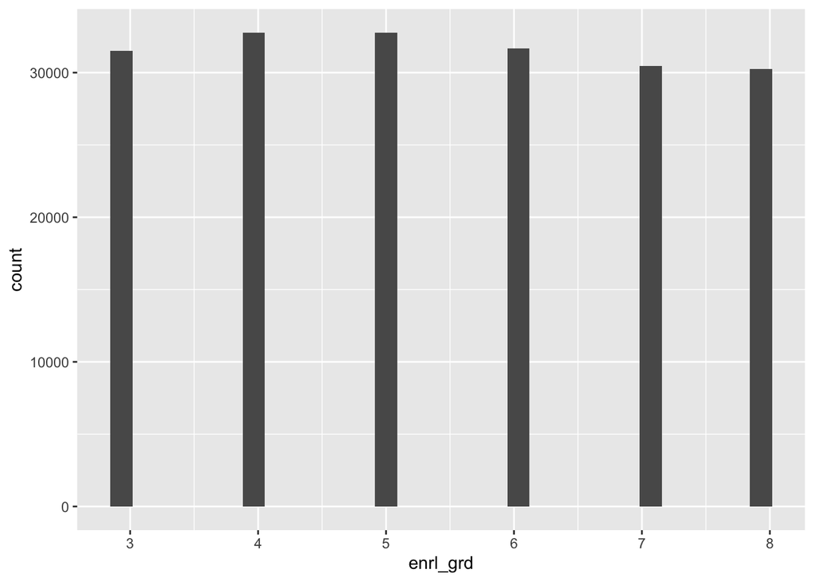

```r
ggplot(df2, aes(x = enrl_grd)) + geom_histogram()
```

```r
psych::describe(df2$score)
```

```
##    vars      n    mean     sd median trimmed    mad  min  max range  skew
## X1    1 189426 2498.99 115.83   2498 2498.75 114.16 1601 3550  1949 -0.03
##    kurtosis   se
## X1     0.52 0.27
```

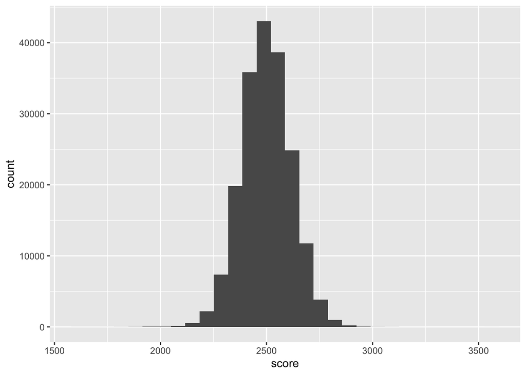

```r
ggplot(df2, aes(x = score)) + geom_histogram()
```

### Task 2.5

Prepare a recipe using the recipe() and prep() functions from the recipes package for final transformation of the variables in this dataset.

```r
outcome = c('score')

id = c('id')

numeric = c('enrl_grd')

cylic <- c('date', 'month')

categorical <- c('sex','ethnic_cd','tst_bnch','migrant_ed_fg','ind_ed_fg','sp_ed_fg','tag_ed_fg','econ_dsvntg','stay_in_dist','stay_in_schl','dist_sped','trgt_assist_fg','ayp_dist_partic','ayp_schl_partic','ayp_dist_prfrm','ayp_schl_prfrm','rc_dist_partic','rc_schl_partic','rc_dist_prfrm','rc_schl_prfrm','grp_rpt_dist_partic','grp_rpt_schl_partic','grp_rpt_dist_prfrm','grp_rpt_schl_prfrm')

for(i in categorical){
    df2[,i] <- as.factor(df2[,i])
}
```

```r
blueprint <- recipe(x  = df2,
                    vars  = c(categorical,numeric,cylic,outcome,id),
                    roles = c(rep('predictor',ncol(df2)-2),'outcome','ID')) %>%
  # for all predictors, create an indicator variable for missingness
  step_indicate_na(all_of(categorical),all_of(numeric)) %>%

  # Remove the variable with zero variance, this will also remove the missingness
  # variables if there is no missingess

  step_zv(all_numeric()) %>%

  # Impute the missing values using mean and mode. You can instead use a
  # more advanced imputation model such as bagged trees. I haven't used it due
  # to time concerns

  step_impute_mean(all_of(numeric)) %>%
  step_impute_mode(all_of(categorical)) %>%

  # cylic date
  step_harmonic(date, frequency = 1, cycle_size = 30) %>%
  step_harmonic(month, frequency = 1, cycle_size = 12) %>%

  # Natural splines for numeric variables and proportions

  step_ns(all_of(numeric),deg_free=3) %>%

  # Standardize the natural splines of numeric variables and proportions

  step_normalize(paste0(numeric,'_ns_1'),
                 paste0(numeric,'_ns_2'),
                 paste0(numeric,'_ns_3')) %>%

  # One-hot encoding for all categorical variables

  step_dummy(all_of(categorical),one_hot=TRUE)


blueprint
```

```
## Recipe
##
## Inputs:
##
##       role #variables
##         ID          1
##    outcome          1
##  predictor         27
##
## Operations:
##
## Creating missing data variable indicators for all_of(categorical), all_of(numeric)
## Zero variance filter on all_numeric()
## Mean Imputation for all_of(numeric)
## Mode Imputation for all_of(categorical)
## Harmonic numeric variables for date
## Harmonic numeric variables for month
## Natural Splines on all_of(numeric)
## Centering and scaling for paste0(numeric, "_ns_1"), paste0(numeric, "_ns_...
## Dummy variables from all_of(categorical)
```

```r
prepare <- prep(blueprint,
                training = df2)
```

### Task 2.6

Finally, apply this recipe to the whole dataset and obtain the final version of the dataset with transformed variables. The final dataset should have 189,426 rows and 76 columns as the following:

```r
baked_df2 <- bake(prepare, new_data = df2)

dim(baked_df2)
```

```
## [1] 189426     76
```

```r
head(baked_df2)
```

```
## # A tibble: 6 × 76
##    date month score    id na_ind_ind_ed_fg na_ind_sp_ed_fg na_ind_tag_ed_fg
##   <int> <dbl> <int> <int>            <int>           <int>            <int>
## 1    14     5  2340     1                0               0                0
## 2     5     6  2430     2                0               0                0
## 3     1     5  2551     3                0               0                0
## 4     1     5  2529     5                0               0                0
## 5    22     5  2417     7                0               0                0
## 6    25     5  2620    10                0               0                0
## # … with 69 more variables: na_ind_econ_dsvntg <int>,
## #   na_ind_stay_in_dist <int>, na_ind_stay_in_schl <int>,
## #   na_ind_dist_sped <int>, na_ind_trgt_assist_fg <int>, date_sin_1 <dbl>,
## #   date_cos_1 <dbl>, month_sin_1 <dbl>, month_cos_1 <dbl>,
## #   enrl_grd_ns_1 <dbl>, enrl_grd_ns_2 <dbl>, enrl_grd_ns_3 <dbl>, sex_F <dbl>,
## #   sex_M <dbl>, ethnic_cd_A <dbl>, ethnic_cd_B <dbl>, ethnic_cd_H <dbl>,
## #   ethnic_cd_I <dbl>, ethnic_cd_M <dbl>, ethnic_cd_P <dbl>, …
```

### Task 2.7

Remove the original date and month variables from the dataset as we do not need them anymore because we already created sin and cos terms for each one of them.

```r
baked_df2 = baked_df2 %>% select(-c('date','month'))
```

### Task 2.8

Export the final dataset (189,426 x 74) as a .csv file and upload it to Canvas along your submission.

```r
write.csv(x=baked_df2, file="data/hw1_data2_output.csv")
```